# 2021W AML 2404 2 [B124] AI AND ML LAB

**The Guardians**

- Ankur Kishorbhai Rokad (C0793757)
- Avinash Ravi (C0791941)
- Sahista Patel (C0796681)
- Vishal Sabarinath Venkatesan (C0801202)

```python
import pandas as pd
import numpy as np

# Language cleaning imports
import nltk
from nltk.corpus import stopwords
from nltk.stem.porter import PorterStemmer
from nltk.stem import WordNetLemmatizer
import re

# Profiling imports
import sweetviz as sv
from pandas_profiling import ProfileReport

# Visulization imports
import matplotlib.pyplot as plt
import seaborn as sns

# For clean Visualization
import warnings
warnings.filterwarnings('ignore')
```

## Importing datasets

```python
# True news dataset from kaggle
df_real = pd.read_csv("DataSet/kaggle-True.csv", encoding='utf-8')

# Fake news dataset from kaggle
df_fake = pd.read_csv("DataSet/kaggle-Fake.csv", encoding='utf-8')

# Data Flair news dataset, constist of true and fake news.
df_flair = pd.read_csv("DataSet/data-flair_news_set.csv", encoding='utf-8')
```

## EDA

### Profiling

For exploratory data analysis, we use two profiling tools that provide a comprehensive report of the data.

- Sweetwiz Profiling
- Pandas Profiling

```python
def get_profiling(dataset, name):
    sv_report = sv.analyze(df_real)  # Generating sweetwiz report
    sv_report.show_html(
        f"Analysis/{name}_sweetviz.html")  # Exporting sweetwiz report as .html

    profiling = ProfileReport(dataset)  # Generating pandas profiling report
    profiling.to_file(f"Analysis/{name}_pandas_profiling.html"
                      )  # Exporting pandas profiling report as .html
```

```python
# Generating reports for all three datasets.
get_profiling(df_real, 'real')
get_profiling(df_fake, 'fake')
get_profiling(df_flair, 'flair')
```

```
Report Analysis/real_sweetviz.html was generated! NOTEBOOK/COLAB USERS: the web browser MAY not pop up, regardless, the report IS saved in your notebook/colab files.
```

```
Report Analysis/fake_sweetviz.html was generated! NOTEBOOK/COLAB USERS: the web browser MAY not pop up, regardless, the report IS saved in your notebook/colab files.
```

```
Report Analysis/flair_sweetviz.html was generated! NOTEBOOK/COLAB USERS: the web browser MAY not pop up, regardless, the report IS saved in your notebook/colab files.
```

### Dataset analysis

Identifying features and shape

```python
df_real.sample(5)
```

|  | title | text | subject | date |
| --- | --- | --- | --- | --- |
| 18716 | Stampede in India's financial capital kills at... | MUMBAI (Reuters) - A rush hour stampede killed... | worldnews | September 29, 2017 |
| 277 | U.S. Interior Department wants more oil drilli... | (Reuters) - The Department of the Interior, th... | politicsNews | December 7, 2017 |
| 3841 | Trump to nominate ex-congressman Green to lead... | WASHINGTON (Reuters) - President Donald Trump ... | politicsNews | May 10, 2017 |
| 16024 | Moscow invites 33 Syrian groups to November 18... | MOSCOW (Reuters) - Russia on Tuesday invited 3... | worldnews | October 31, 2017 |
| 13172 | Bolivians spoil ballots in judicial vote to pr... | LA PAZ (Reuters) - More than half the ballots ... | worldnews | December 4, 2017 |

```python
df_fake.head(5)
```

|  | title | text | subject | date |
| --- | --- | --- | --- | --- |
| 0 | Donald Trump Sends Out Embarrassing New Year’... | Donald Trump just couldn t wish all Americans ... | News | December 31, 2017 |
| 1 | Drunk Bragging Trump Staffer Started Russian ... | House Intelligence Committee Chairman Devin Nu... | News | December 31, 2017 |
| 2 | Sheriff David Clarke Becomes An Internet Joke... | On Friday, it was revealed that former Milwauk... | News | December 30, 2017 |
| 3 | Trump Is So Obsessed He Even Has Obama’s Name... | On Christmas day, Donald Trump announced that ... | News | December 29, 2017 |
| 4 | Pope Francis Just Called Out Donald Trump Dur... | Pope Francis used his annual Christmas Day mes... | News | December 25, 2017 |

```python
df_flair.sample(5)
```

|  | Unnamed: 0 | title | text | label |
| --- | --- | --- | --- | --- |
| 2601 | 8739 | Syria conflict: Food rations run out in rebel-... | November 11, 2016 Syria conflict: Food rations... | FAKE |
| 4668 | 10528 | Jerusalem in Photos from 1862: No mosques, no ... | Jerusalem in Photos from 1862: No mosques, no ... | FAKE |
| 4523 | 2091 | Warming of oceans due to climate change is uns... | The warming of the oceans due to climate chang... | REAL |
| 3393 | 921 | 5 takeaways from the New York primary | BROOKLYN — New York is supposed to be a magica... | REAL |
| 930 | 10340 | News Shot: Detroit Airport Uses New System To ... | In this News Shot, Joe Joseph quickly discusse... | FAKE |

```python
print(f"df_real's shape:  {df_real.shape}")
print(f"df_fake's shape:  {df_fake.shape}")
print(f"df_flair's shape: {df_flair.shape}")
```

```
df_real's shape:  (21417, 4)
df_fake's shape:  (23481, 4)
df_flair's shape: (6335, 4)
```

### Count plot for different categories of news

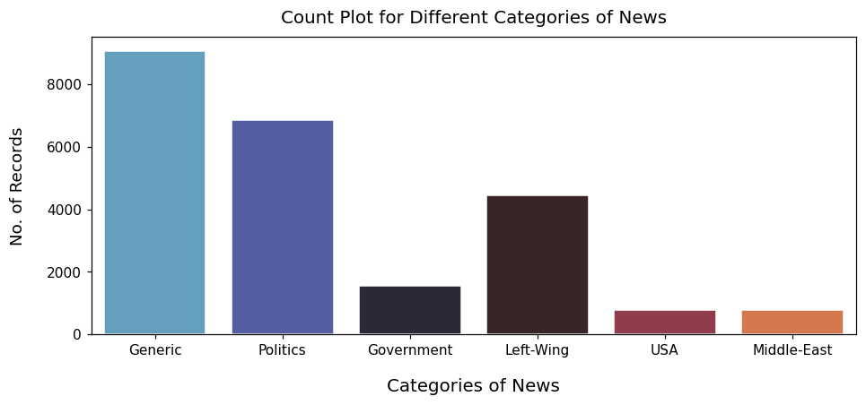

```python
f, axes = plt.subplots(figsize=(10, 4), dpi=110, frameon=False)
sns.countplot(x="subject",
              palette="icefire",
              edgecolor="1",
              data=df_fake,
              ax=axes)
axes.set_xticklabels(labels=[
    'Generic', 'Politics', 'Government', 'Left-Wing', 'USA', 'Middle-East'
],
                     fontdict={"fontsize": 10})
axes.set_xlabel('Categories of News',
                fontdict={
                    "fontsize": 13,
                    'fontweight': 3
                },
                labelpad=15)
axes.set_ylabel('No. of Records',
                fontdict={
                    "fontsize": 12,
                    'fontweight': 2
                },
                labelpad=15)
axes.set_title('Count Plot for Different Categories of News',
               fontdict={
                   "fontsize": 13,
                   'fontweight': 3
               },
               pad=10)
```

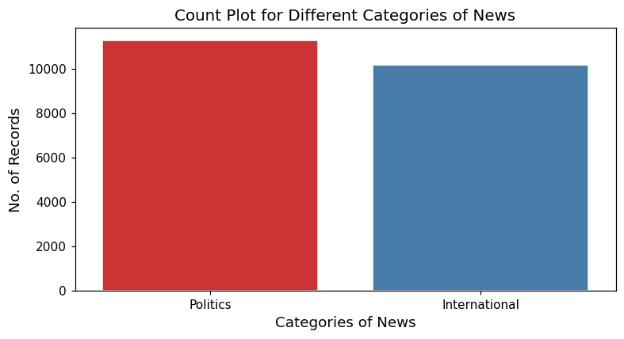

```python
f, axes = plt.subplots(figsize=(8, 4), dpi=110, frameon=False)
sns.countplot(x="subject",
              palette="Set1",
              edgecolor="1",
              data=df_real,
              ax=axes)
axes.set_xticklabels(labels=['Politics', 'International'],
                     fontdict={"fontsize": 10})
axes.set_xlabel('Categories of News',
                fontdict={
                    "fontsize": 12,
                    'fontweight': 2
                })
axes.set_ylabel('No. of Records', fontdict={"fontsize": 12, 'fontweight': 2})
axes.set_title('Count Plot for Different Categories of News',
               fontdict={
                   "fontsize": 13,
                   'fontweight': 2
               })
```

## Data cleaning

### Null handling

```python
print("{:<18} {:<12} {:<7} {:<50} {}".format('DataSource', 'Shape', 'Nulls',
                                             'Columns', 'Column-wise Nulls'))
print("{:<18} {:<12} {:<7} {:<50} {}".format(17 * '-', 12 * '-', 7 * '-',
                                             50 * '-', 25 * '-'))
print("\n{:<18} {:<12} {:<7} {:<50} {}".format(
    'Kaggle Real-News', str(df_real.shape),
    str(sum(df_real.isnull().sum().tolist())), str(list(df_real.columns)),
    str(df_real.isnull().sum().tolist())))
print("{:<18} {:<12} {:<7} {:<50} {}".format(
    'Kaggle Fake-News', str(df_fake.shape),
    str(sum(df_fake.isnull().sum().tolist())), str(list(df_fake.columns)),
    str(df_fake.isnull().sum().tolist())))
print("{:<18} {:<12} {:<7} {:<50} {}".format(
    'Flair', str(df_flair.shape), str(sum(df_flair.isnull().sum().tolist())),
    str(list(df_flair.columns)), str(df_flair.isnull().sum().tolist())))
print("\n{:<18} {:<12} {:<7} {:<50} {}".format(17 * '-', 12 * '-', 7 * '-',
                                               50 * '-', 25 * '-'))
total = df_real.shape[0] + df_fake.shape[0] + df_flair.shape[0]
nulls = sum(df_real.isnull().sum().tolist()) + sum(
    df_fake.isnull().sum().tolist()) + sum(df_flair.isnull().sum().tolist())
remain = total - nulls
print("{:<18} {:<12} {:<7} {:<50} {}".format(
    'Total', 'Rows-' + str(total), str(nulls),
    str(
        list(
            set(list(df_real.columns)) | set(list(df_fake.columns))
            | set(list(df_flair.columns)))), ''))
print('\n\nDropping Nulls - After Max damage remain: ', remain)
```

```
DataSource         Shape        Nulls   Columns                                            Column-wise Nulls
-----------------  ------------ ------- -------------------------------------------------- -------------------------

Kaggle Real-News   (21417, 4)   0       ['title', 'text', 'subject', 'date']               [0, 0, 0, 0]
Kaggle Fake-News   (23481, 4)   0       ['title', 'text', 'subject', 'date']               [0, 0, 0, 0]
Flair              (6335, 4)    0       ['Unnamed: 0', 'title', 'text', 'label']           [0, 0, 0, 0]

-----------------  ------------ ------- -------------------------------------------------- -------------------------
Total              Rows-51233   0       ['title', 'date', 'label', 'Unnamed: 0', 'text', 'subject']


Dropping Nulls - After Max damage remain:  51233
```

### Uniformity

**Text format**

Looking at the Sample data, focusing on 'Text' column values:

- Real news data frame: has publication and source of news starting of the text
- Fake news data frame: Doesn't
- Flair news data frame: Doesn't

It is important to make it unified before merging them and preparing them for modelling.

```python
# Extracting list without publications
without_pub = []
for index, row in enumerate(df_real.text.values):
    try:
        # Try will throw excution to except if publisher not found
        record = row.split(" -", maxsplit=1)
        record[1]
        # Setting publisher text limit 260 [This much longer Publisher name is risk to text loss]
        # Following will give error, ensuring no text having "-" in between is counted
        assert (len(record[0]) < 260)
    except:
        without_pub.append(index)
```

```python
# Check the length and data without publisher
df_real.iloc[without_pub].text
```

```
3488     The White House on Wednesday disclosed a group...
4358     Neil Gorsuch, President Donald Trump’s appoint...
4465     WASHINGTON The clock began running out this we...
5784     Federal appeals court judge Neil Gorsuch, the ...
6660     Republican members of Congress are complaining...
6823     Over the course of the U.S. presidential campa...
7922     After going through a week reminiscent of Napo...
8194     The following timeline charts the origin and s...
8195     Global health officials are racing to better u...
8247     U.S. President Barack Obama visited a street m...
8465     ALGONAC, MICH.—Parker Fox drifted out of the D...
8481     Global health officials are racing to better u...
8482     The following timeline charts the origin and s...
8505     Global health officials are racing to better u...
8506     The following timeline charts the origin and s...
8771     In a speech weighted with America’s complicate...
8970
9008     The following timeline charts the origin and s...
9009     Global health officials are racing to better u...
9307     It’s the near future, and North Korea’s regime...
9618     GOP leaders have unleashed a stunning level of...
9737     Caitlyn Jenner posted a video on Wednesday (Ap...
10479    The Democratic and Republican nominees for the...
Name: text, dtype: object
```

```python
print(f'No. of news without publisher: {len(df_real.iloc[without_pub].text)}')
```

```
No. of news without publisher: 23
```

```python
# Checking for rows with empty text
[
    index for index, text in enumerate(df_real.text.values)
    if str(text).strip() == ''
]
```

```
[8970]
```

```python
# Dropping this record
real = df_real.drop(8970, axis=0)
```

```python
# Seperating Publication from text values
publ = []
tmp_text = []
for index, row in enumerate(df_real.text.values):
    if index in without_pub:
        tmp_text.append(row)
        # Adding Unknown as for the rows which found without publishers
        publ.append("Unknown")
        continue
    record = row.split(" -", maxsplit=1)
    publ.append(record[0])
    tmp_text.append(record[1])
```

```python
# Adding seperate column for publication info and Replace existing text column with new text
df_real["publisher"] = publ
df_real["text"] = tmp_text
```

```python
df_real.sample(5)
```

|  | title | text | subject | date | publisher |
| --- | --- | --- | --- | --- | --- |
| 14410 | Beijing orders safety checks after apartment b... | A fire in a Beijing apartment block that kill... | worldnews | November 20, 2017 | BEIJING (Reuters) |
| 8429 | Clinton Foundation to bar foreign, corporate f... | The Clinton Foundation will stop accepting fo... | politicsNews | August 18, 2016 | WASHINGTON (Reuters) |
| 14036 | Islamic State beheads 15 of its own fighters: ... | Islamic State beheaded 15 of its own fighters... | worldnews | November 23, 2017 | JALALABAD, Afghanistan (Reuters) |
| 5404 | Trump says U.S. media reports making it hard t... | President Donald Trump on Thursday said repor... | politicsNews | February 16, 2017 | WASHINGTON (Reuters) |
| 14818 | Kenya court throws out opposition coalition fr... | Kenya s Supreme Court on Tuesday rejected the... | worldnews | November 14, 2017 | NAIROBI (Reuters) |

Same Way For FakeNews

```python
# Extracting list without publications
without_pub = []
for index, row in enumerate(df_fake.text.values):
    try:
        # Try will throw excution to except if publisher not found
        record = row.split(" -", maxsplit=1)
        record[1]
        # Setting publisher text limit 260 [This much longer Publisher name is risk to text loss]
        # Following will give error, ensuring no text having "-" in between is counted
        assert (len(record[0]) < 260)
    except:
        without_pub.append(index)
```

```python
print(
    f'No. of news without publisher: {len(df_fake.iloc[without_pub].text)}\nTotal Length: {len(df_fake.text)}'
)
```

```
No. of news without publisher: 23422
Total Length: 23481
```

```python
# Seperating Publication from text values
publ = []
tmp_text = []
for index, row in enumerate(df_fake.text.values):
    if index in without_pub:
        tmp_text.append(row)
        # Adding Unknown as for the rows which found without publishers
        publ.append("Unknown")
        continue
    record = row.split(" -", maxsplit=1)
    publ.append(record[0])
    tmp_text.append(record[1])
```

```python
# Adding seperate column for publication info and Replace existing text column with new text
df_fake["publisher"] = publ
df_fake["text"] = tmp_text
```

```python
df_fake.sample(5)
```

|  | title | text | subject | date | publisher |
| --- | --- | --- | --- | --- | --- |
| 18565 | BOOM! HARRIS FAULKNER Blows Up The Russia Coll... | Fox News Harris Faulkner BLOWS UP the WHOLE R... | left-news | May 29, 2017 | Unknown |
| 13706 | TRUMP IS RIGHT AGAIN! While Pundits and Politi... | This is an odd report from Press TV because a ... | politics | Jun 12, 2016 | Unknown |
| 8362 | Richard Dreyfuss Uses GMA Interview To Troll ... | Legendary actor Richard Dreyfuss has been hitt... | News | February 3, 2016 | Unknown |
| 2416 | Trump Is ACTIVELY Working To RIP Families Awa... | A letter to the editor appeared in The New Yor... | News | February 23, 2017 | Unknown |
| 9609 | CNN’S DRAMA QUEEN HOST Tears Up After Reading ... | CNN s Don Lemon gave an OSCAR-worthy performan... | politics | Oct 24, 2017 | Unknown |

```python
# Checking for the same in fake news
empty_fake_index = [
    index for index, text in enumerate(df_fake.text.values)
    if str(text).strip() == ''
]
print(f"No of empty rows: {len(empty_fake_index)}")
df_fake.iloc[empty_fake_index].tail()
```

```
No of empty rows: 630
```

|  | title | text | subject | date | publisher |
| --- | --- | --- | --- | --- | --- |
| 21816 | BALTIMORE BURNS: MARYLAND GOVERNOR BRINGS IN N... |  | left-news | Apr 27, 2015 | Unknown |
| 21826 | FULL VIDEO: THE BLOCKBUSTER INVESTIGATION INTO... |  | left-news | Apr 25, 2015 | Unknown |
| 21827 | (VIDEO) HILLARY CLINTON: RELIGIOUS BELIEFS MUS... |  | left-news | Apr 25, 2015 | Unknown |
| 21857 | (VIDEO)ICE PROTECTING OBAMA: WON’T RELEASE NAM... |  | left-news | Apr 14, 2015 | Unknown |
| 21873 | (VIDEO) HYSTERICAL SNL TAKE ON HILLARY’S ANNOU... |  | left-news | Apr 12, 2015 | Unknown |

Total 630 rows which has text column empty  
Instead having all news in title column - merging title values to text column  
Making Full-News as 'text' single column will solve this problem

```python
# First Let's make single dataset for both kaggle source
# Two different files for binary classification
# Adding feature 'label'
# Real = 1 & Fake = 0
df_real['label'] = 1
df_fake['label'] = 0
```

```python
# Concatinating two kaggle source DataSet
df = pd.concat([df_real, df_fake]).reset_index(drop=True)
df.head()
```

|  | title | text | subject | date | publisher |
| --- | --- | --- | --- | --- | --- |
| 0 | As U.S. budget fight looms, Republicans flip t... | The head of a conservative Republican faction... | politicsNews | December 31, 2017 | WASHINGTON (Reuters) |
| 1 | U.S. military to accept transgender recruits o... | Transgender people will be allowed for the fi... | politicsNews | December 29, 2017 | WASHINGTON (Reuters) |
| 2 | Senior U.S. Republican senator: 'Let Mr. Muell... | The special counsel investigation of links be... | politicsNews | December 31, 2017 | WASHINGTON (Reuters) |
| 3 | FBI Russia probe helped by Australian diplomat... | Trump campaign adviser George Papadopoulos to... | politicsNews | December 30, 2017 | WASHINGTON (Reuters) |
| 4 | Trump wants Postal Service to charge 'much mor... | President Donald Trump called on the U.S. Pos... | politicsNews | December 29, 2017 | SEATTLE/WASHINGTON (Reuters) |

```python
df['text'] = df['title'] + ' ' + df['text']
df.head()
```

|  | title | text | subject | date | publisher |
| --- | --- | --- | --- | --- | --- |
| 0 | As U.S. budget fight looms, Republicans flip t... | As U.S. budget fight looms, Republicans flip t... | politicsNews | December 31, 2017 | WASHINGTON (Reuters) |
| 1 | U.S. military to accept transgender recruits o... | U.S. military to accept transgender recruits o... | politicsNews | December 29, 2017 | WASHINGTON (Reuters) |
| 2 | Senior U.S. Republican senator: 'Let Mr. Muell... | Senior U.S. Republican senator: 'Let Mr. Muell... | politicsNews | December 31, 2017 | WASHINGTON (Reuters) |
| 3 | FBI Russia probe helped by Australian diplomat... | FBI Russia probe helped by Australian diplomat... | politicsNews | December 30, 2017 | WASHINGTON (Reuters) |
| 4 | Trump wants Postal Service to charge 'much mor... | Trump wants Postal Service to charge 'much mor... | politicsNews | December 29, 2017 | SEATTLE/WASHINGTON (Reuters) |

```python
print('\n' + 15 * '-' + 'Kaggle Source' + 15 * '-')
my_dict = {
    'title': 'The title of the article',
    'text': 'The text of the article',
    'subject': 'The subject of the article',
    'date': 'The date at which the article was posted',
    'label': 'Fake=0/Real=1'
}
df_attr = pd.DataFrame(list(my_dict.items()),
                       columns=['Attribute Information', 'Values'])

df_attr.style.hide_index().set_table_styles([
    dict(selector='th', props=[('text-align', 'left')])
]).set_properties(**{'text-align': 'left'})
```

```
---------------Kaggle Source---------------
```

| Attribute Information | Values |
| --- | --- |
| title | The title of the article |
| text | The text of the article |
| subject | The subject of the article |
| date | The date at which the article was posted |
| label | Fake=0/Real=1 |

```python
print('\n' + 15 * '-' + 'Flair Source' + 15 * '-')
my_dict = {
    'id': 'Unique Number',
    'title': 'The title of the article',
    'text': 'The text of the article',
    'label': 'Fake=FAKE/Real=REAL'
}
df_attr = pd.DataFrame(list(my_dict.items()),
                       columns=['Attribute Information', 'Values'])

df_attr.style.hide_index().set_table_styles([
    dict(selector='th', props=[('text-align', 'left')])
]).set_properties(**{'text-align': 'left'})
```

```
---------------Flair Source---------------
```

| Attribute Information | Values |
| --- | --- |
| id | Unique Number |
| title | The title of the article |
| text | The text of the article |
| label | Fake=FAKE/Real=REAL |

```python
print('\n' + 15 * '-' + 'Kaggle Source' + 15 * '-' + '\n')
df.info()
```

```
---------------Kaggle Source---------------

<class 'pandas.core.frame.DataFrame'>
RangeIndex: 44898 entries, 0 to 44897
Data columns (total 5 columns):
 #   Column     Non-Null Count  Dtype
---  ------     --------------  -----
 0   title      44898 non-null  object
 1   text       44898 non-null  object
 2   subject    44898 non-null  object
 3   date       44898 non-null  object
 4   publisher  44898 non-null  object
dtypes: object(5)
memory usage: 1.7+ MB
```

```python
print('\n' + 15 * '-' + 'Flair Source' + 15 * '-' + '\n')
df_flair.info()
```

```
---------------Flair Source---------------

<class 'pandas.core.frame.DataFrame'>
RangeIndex: 6335 entries, 0 to 6334
Data columns (total 4 columns):
 #   Column      Non-Null Count  Dtype
---  ------      --------------  -----
 0   Unnamed: 0  6335 non-null   int64
 1   title       6335 non-null   object
 2   text        6335 non-null   object
 3   label       6335 non-null   object
dtypes: int64(1), object(3)
memory usage: 198.1+ KB
```

We need to make Flair DataSet uniformity with kaggle

```python
# Let's Check Flair samples again
df_flair.sample(5)
```

|  | Unnamed: 0 | title | text | label |
| --- | --- | --- | --- | --- |
| 5130 | 9988 | Lara Trump Implies FBI Letter Politically Moti... | Lara Trump Implies FBI Letter Politically Moti... | FAKE |
| 2487 | 362 | Defense Secretary Carter endorses 3-year timel... | Defense Secretary Ash Carter on Wednesday endo... | REAL |
| 5400 | 5950 | JUST IN: Trump Camp Caught On Cam Bragging Of ... | Comments \nConsultant Jesse Benton of the pro-... | FAKE |
| 2423 | 5819 | Biden and Trump Agree to Fight Pistol Duel--Fi... | Thursday, 27 October 2016 Biden and Trump to D... | FAKE |
| 3410 | 4481 | Senate Debate Reveals Absurd Level Of Trade De... | The pair noted that although legislators are a... | REAL |

```python
# Here, No issue with text, No publisher included in that.
# Let's check if any null text available
empty_flair_index = [
    index for index, text in enumerate(df_flair.text.values)
    if str(text).strip() == ''
]
print(f"No of empty rows: {len(empty_flair_index)}")
df_flair.iloc[empty_flair_index].tail()
```

```
No of empty rows: 36
```

|  | Unnamed: 0 | title | text | label |
| --- | --- | --- | --- | --- |
| 5699 | 9467 | A Fifth Clinton Presidency? Hill, No! |  | FAKE |
| 5772 | 5324 | Huma’s Weiner Dogs Hillary |  | FAKE |
| 6064 | 6127 | Radio Derb: Peak White Guilt, PC Now To The LE... |  | FAKE |
| 6175 | 7043 | Hillary’s High Crimes & Misdemeanors Threaten ... |  | FAKE |
| 6328 | 9337 | Radio Derb Is On The Air–Leonardo And Brazil’s... |  | FAKE |

```python
# Same way merging title of the news with text column
df_flair['text'] = df_flair['title'] + ' ' + df_flair['text']
df_flair.head()
```

|  | Unnamed: 0 | title | text | label |
| --- | --- | --- | --- | --- |
| 0 | 8476 | You Can Smell Hillary’s Fear | You Can Smell Hillary’s Fear Daniel Greenfield... | FAKE |
| 1 | 10294 | Watch The Exact Moment Paul Ryan Committed Pol... | Watch The Exact Moment Paul Ryan Committed Pol... | FAKE |
| 2 | 3608 | Kerry to go to Paris in gesture of sympathy | Kerry to go to Paris in gesture of sympathy U.... | REAL |
| 3 | 10142 | Bernie supporters on Twitter erupt in anger ag... | Bernie supporters on Twitter erupt in anger ag... | FAKE |
| 4 | 875 | The Battle of New York: Why This Primary Matters | The Battle of New York: Why This Primary Matte... | REAL |

```python
# As we have our dataframe with lables Fake=0 and Real=1
# Need to map this dataset label with same, too
labels = dict(FAKE=0, REAL=1)
df_flair['label'] = df_flair['label'].map(labels)
```

```python
df_flair.head()
```

|  | Unnamed: 0 | title | text | label |
| --- | --- | --- | --- | --- |
| 0 | 8476 | You Can Smell Hillary’s Fear | You Can Smell Hillary’s Fear Daniel Greenfield... | 0 |
| 1 | 10294 | Watch The Exact Moment Paul Ryan Committed Pol... | Watch The Exact Moment Paul Ryan Committed Pol... | 0 |
| 2 | 3608 | Kerry to go to Paris in gesture of sympathy | Kerry to go to Paris in gesture of sympathy U.... | 1 |
| 3 | 10142 | Bernie supporters on Twitter erupt in anger ag... | Bernie supporters on Twitter erupt in anger ag... | 0 |
| 4 | 875 | The Battle of New York: Why This Primary Matters | The Battle of New York: Why This Primary Matte... | 1 |

```python
# Time to remove unnecessary columns and merging all dataframes
df = df.drop(["subject", "date", "title", "publisher"], axis=1)
df_flair = df_flair.drop(["Unnamed: 0", "title"], axis=1)
df = df.append(df_flair, ignore_index=True)
df
```

|  | text | label |
| --- | --- | --- |
| 0 | As U.S. budget fight looms, Republicans flip t... | NaN |
| 1 | U.S. military to accept transgender recruits o... | NaN |
| 2 | Senior U.S. Republican senator: 'Let Mr. Muell... | NaN |
| 3 | FBI Russia probe helped by Australian diplomat... | NaN |
| 4 | Trump wants Postal Service to charge 'much mor... | NaN |
| ... | ... | ... |
| 51228 | State Department says it can't find emails fro... | 1.0 |
| 51229 | The ‘P’ in PBS Should Stand for ‘Plutocratic’ ... | 0.0 |
| 51230 | Anti-Trump Protesters Are Tools of the Oligarc... | 0.0 |
| 51231 | In Ethiopia, Obama seeks progress on peace, se... | 1.0 |
| 51232 | Jeb Bush Is Suddenly Attacking Trump. Here's W... | 1.0 |

51233 rows × 2 columns

### Handling Duplicate Values

```python
df.nunique()
```

```
text     45410
label        2
dtype: int64
```

```python
df['text'].duplicated().value_counts()
```

```
False    45410
True      5823
Name: text, dtype: int64
```

```python
df[df['text'].duplicated() == True]
```

|  | text | label |
| --- | --- | --- |
| 445 | Senate tax bill stalls on deficit-focused 'tri... | NaN |
| 778 | Trump warns 'rogue regime' North Korea of grav... | NaN |
| 892 | Republicans unveil tax cut bill, but the hard ... | NaN |
| 896 | Trump taps Fed centrist Powell to lead U.S. ce... | NaN |
| 974 | Two ex-Trump aides charged in Russia probe, th... | NaN |
| ... | ... | ... |
| 50864 | There’s a good reason protesters at the Univer... | 1.0 |
| 50981 | Biden Blames “Lazy American Women” For The Eco... | 0.0 |
| 51046 | Hillary’s “Big Tent” is Obama’s “Grand Bargain... | 0.0 |
| 51125 | ISIS uses an industrial dough kneader to kill ... | 0.0 |
| 51131 | North Korea Threatens ‘Sacred’ Nuclear War Aga... | 0.0 |

5823 rows × 2 columns

```python
df['text'].iloc[778]
```

```
"Trump warns 'rogue regime' North Korea of grave danger  U.S. President Donald Trump arrived in China on Wednesday seeking help to rein in North Korea, telling the reclusive state’s leader he was putting his country in grave danger by developing nuclear weapons. Trump used some of his toughest langu…
```

```python
for i in range(len(df)):
    if df['text'].iloc[i] == df['text'].iloc[778]:
        print(i)
```

```
762
778
```

```python
df['text'].iloc[762]
```

```
"Trump warns 'rogue regime' North Korea of grave danger  U.S. President Donald Trump arrived in China on Wednesday seeking help to rein in North Korea, telling the reclusive state’s leader he was putting his country in grave danger by developing nuclear weapons. Trump used some of his toughest langu…
```

```python
df.drop_duplicates(subset=['text'], inplace=True)
```

```python
df.info()
```

```
<class 'pandas.core.frame.DataFrame'>
Int64Index: 45410 entries, 0 to 51232
Data columns (total 2 columns):
 #   Column  Non-Null Count  Dtype
---  ------  --------------  -----
 0   text    45410 non-null  object
 1   label   6306 non-null   float64
dtypes: float64(1), object(1)
memory usage: 1.0+ MB
```

*As we are done with removing all the duplicate values in our dataset, we can go ahead with Language Cleaning, that is to remove special charecters, symbols, emois, URLs etc.*

## Language Cleaning

We remove urls (if any)  
Perform decontractions  
Non-acronize few popular words  
Typos, slang and informal abbreviations  
Character entity references  
Remove HTML tags  
Remove emoticons, symbols, pictoraphs, transport and map symbols & flags  
Remove punctuations and all special characters  
Remove stopwords

```python
nltk_stopwords = stopwords.words('english')
stopwords = set(nltk_stopwords)
print(stopwords)
```

```
{'needn', 're', "weren't", 'has', 'of', 've', 'had', 'her', "should've", "you'd", 'he', 'they', "she's", 'down', 'ma', "wouldn't", 'about', 'wouldn', 'your', "won't", 'can', 'wasn', 'all', 'because', "doesn't", 'yourselves', 'him', 'be', 'nor', 'who', 'or', 'and', 's', 'am', 'hadn', "you've", 'thems…
```

```python
ps = PorterStemmer()
lm = WordNetLemmatizer()
```

```python
def clean_text(text):

    text = re.sub("http\S+", '', str(text))

    # Contractions ref: https://www.kaggle.com/gunesevitan/nlp-with-disaster-tweets-eda-cleaning-and-bert
    text = re.sub(r"he's", "he is", str(text))
    text = re.sub(r"there's", "there is", str(text))
    text = re.sub(r"We're", "We are", str(text))
    text = re.sub(r"That's", "That is", str(text))
    text = re.sub(r"won't", "will not", str(text))
    text = re.sub(r"they're", "they are", str(text))
    text = re.sub(r"Can't", "Cannot", str(text))
    text = re.sub(r"wasn't", "was not", str(text))
    text = re.sub(r"aren't", "are not", str(text))
    text = re.sub(r"isn't", "is not", str(text))
    text = re.sub(r"What's", "What is", str(text))
    text = re.sub(r"haven't", "have not", str(text))
    text = re.sub(r"hasn't", "has not", str(text))
    text = re.sub(r"There's", "There is", str(text))
    text = re.sub(r"He's", "He is", str(text))
    text = re.sub(r"It's", "It is", str(text))
    text = re.sub(r"You're", "You are", str(text))
    text = re.sub(r"I'M", "I am", str(text))
    text = re.sub(r"shouldn't", "should not", str(text))
    text = re.sub(r"wouldn't", "would not", str(text))
    text = re.sub(r"i'm", "I am", str(text))
    text = re.sub(r"I'm", "I am", str(text))
    text = re.sub(r"Isn't", "is not", str(text))
    text = re.sub(r"Here's", "Here is", str(text))
    text = re.sub(r"you've", "you have", str(text))
    text = re.sub(r"we're", "we are", str(text))
    text = re.sub(r"what's", "what is", str(text))
    text = re.sub(r"couldn't", "could not", str(text))
    text = re.sub(r"we've", "we have", str(text))
    text = re.sub(r"who's", "who is", str(text))
    text = re.sub(r"y'all", "you all", str(text))
    text = re.sub(r"would've", "would have", str(text))
    text = re.sub(r"it'll", "it will", str(text))
    text = re.sub(r"we'll", "we will", str(text))
    text = re.sub(r"We've", "We have", str(text))
    text = re.sub(r"he'll", "he will", str(text))
    text = re.sub(r"Y'all", "You all", str(text))
    text = re.sub(r"Weren't", "Were not", str(text))
    text = re.sub(r"Didn't", "Did not", str(text))
    text = re.sub(r"they'll", "they will", str(text))
    text = re.sub(r"they'd", "they would", str(text))
    text = re.sub(r"DON'T", "DO NOT", str(text))
    text = re.sub(r"they've", "they have", str(text))
    text = re.sub(r"i'd", "I would", str(text))
    text = re.sub(r"should've", "should have", str(text))
    text = re.sub(r"where's", "where is", str(text))
    text = re.sub(r"we'd", "we would", str(text))
    text = re.sub(r"i'll", "I will", str(text))
    text = re.sub(r"weren't", "were not", str(text))
    text = re.sub(r"They're", "They are", str(text))
    text = re.sub(r"let's", "let us", str(text))
    text = re.sub(r"it's", "it is", str(text))
    text = re.sub(r"can't", "cannot", str(text))
    text = re.sub(r"don't", "do not", str(text))
    text = re.sub(r"you're", "you are", str(text))
    text = re.sub(r"i've", "I have", str(text))
    text = re.sub(r"that's", "that is", str(text))
    text = re.sub(r"i'll", "I will", str(text))
    text = re.sub(r"doesn't", "does not", str(text))
    text = re.sub(r"i'd", "I would", str(text))
    text = re.sub(r"didn't", "did not", str(text))
    text = re.sub(r"ain't", "am not", str(text))
    text = re.sub(r"you'll", "you will", str(text))
    text = re.sub(r"I've", "I have", str(text))
    text = re.sub(r"Don't", "do not", str(text))
    text = re.sub(r"I'll", "I will", str(text))
    text = re.sub(r"I'd", "I would", str(text))
    text = re.sub(r"Let's", "Let us", str(text))
    text = re.sub(r"you'd", "You would", str(text))
    text = re.sub(r"It's", "It is", str(text))
    text = re.sub(r"Ain't", "am not", str(text))
    text = re.sub(r"Haven't", "Have not", str(text))
    text = re.sub(r"Could've", "Could have", str(text))
    text = re.sub(r"youve", "you have", str(text))

    # Abbreviations
    text = re.sub("U.S.", "United States", str(text))
    text = re.sub("Dec", "December", str(text))
    text = re.sub("Jan.", "January", str(text))

    # Typos, slang and informal abbreviations
    text = re.sub(r"w/e", "whatever", str(text))
    text = re.sub(r"w/", "with", str(text))
    text = re.sub(r"USAgov", "USA government", str(text))
    text = re.sub(r"recentlu", "recently", str(text))
    text = re.sub(r"Ph0tos", "Photos", str(text))
    text = re.sub(r"amirite", "am I right", str(text))
    text = re.sub(r"exp0sed", "exposed", str(text))
    text = re.sub(r"<3", "love", str(text))
    text = re.sub(r"amageddon", "armageddon", str(text))
    text = re.sub(r"Trfc", "Traffic", str(text))
    text = re.sub(r"WindStorm", "Wind Storm", str(text))
    text = re.sub(r"TRAUMATISED", "traumatized", str(text))

    # Character entity references
    text = re.sub(r"&gt;", ">", str(text))
    text = re.sub(r"&lt;", "<", str(text))
    text = re.sub(r"&amp;", "&", str(text))

    # Remove Urls
    url = re.compile(r'https?://\S+|www\.\S+')
    text = url.sub(r'', text)

    # Remove HTML tags
    html = re.compile(r'<.*?>')
    text = html.sub(r'', text)

    # Remove emoticons, symbols, pictoraphs, transport and map symbols & flags
    emoji_pattern = re.compile(
        "["
        u"\U0001F600-\U0001F64F"
        u"\U0001F300-\U0001F5FF"
        u"\U0001F680-\U0001F6FF"
        u"\U0001F1E0-\U0001F1FF"
        u"\U00002702-\U000027B0"
        u"\U000024C2-\U0001F251"
        "]+",
        flags=re.UNICODE)
    text = emoji_pattern.sub(r'', text)

    # Punctuations & special characters
    text = re.sub("[^A-Za-z0-9]+", " ", str(text))

    # Stop word removal
    text = [str(i).lower() for i in text.split() if i.lower() not in stopwords]

    # Stemming the words
    text = [ps.stem(word) for word in text]

    # Lemmatizing the words
    text = [lm.lemmatize(word) for word in text]

    # Joining back to a sentence
    text = ' '.join(text)

    return text
```

```python
df['text'] = df['text'].map(lambda x: clean_text(x))
```

```python
df['text']
```

```
0        unit state budget fight loom republican flip f...
1        unit state militari accept transgend recruit m...
2        senior unit state republican senat let mr muel...
3        fbi russia probe help australian diplomat tip ...
4        trump want postal servic charg much amazon shi...
                               ...
51228    state depart say cannot find email clinton spe...
51229    p pb stand plutocrat pentagon p pb stand pluto...
51230    anti trump protest tool oligarchi inform anti ...
51231    ethiopia obama seek progress peac secur east a...
51232    jeb bush suddenli attack trump matter jeb bush...
Name: text, Length: 45410, dtype: object
```

## Exporting the cleaned dataset

```python
df.to_csv('DataSet/clean_ds.csv', index=False, header=True)
```